# A3: Incarceration

### Introduction

An introduction of the problem domain and a description of the variable(s) you are choosing to analyze (and why!)

The issue with the united states prision system is moraly inefective, as well as racialy biass. In fact, lack Americans are incarcerated at a state average of 1,240 per 100,000 residents, whereas Latino Americans are imprisoned at a rate of 349 per 100,000 residents. White, non-Latino Americans, meanwhile, are incarcerated at 261 per 100,000 residents. To add, 76 percent of all inmates end up back in jail within five years. In order to solve the problem, we need to indetify the issue through data. This is what I will be trying to through this assignment.

### Summary Information

These will likely be calculated using your DPLYR skills, answering questions such as:

- What is the average value of my variable across all the counties (in the current year)?
- Where is my variable the highest / lowest?
- How much has my variable change over the last N years?

Feel free to calculate and report values that you find relevant. Again, remember that the purpose is to think about how these measure of incarceration vary by race.

### The Dataset

The person who colected the dataset was the Vera Institute of Justice. This was made possible by Robert W. Wilson Charitable Trust, who funded a team to explore this topic. The data was collected includes data from the 2016 and 2017 ASJ, and 2016 NCRP, and produced 50 State Fact Sheets using the Incarceration Trends dataset. This data sheet includes of 23 features and 153811 observations in the data set. Looking at the data sheet, an ethical question could be how the races corespond to the number of prison of population.

### Trends Over Time Chart

Include a chart. Make sure to describe why you included the chart, and what patterns emerged

The first chart that you will create and include will show the trend over time of your variable/topic. Think carefully about what you want to communicate to your user (you may have to find relevant trends in the dataset first!). Here are some requirements to help guide your design:

- Show more than one, but fewer than ~10 trends
  - This may mean showing the same measure for different locations or different racial groups. Think carefully about a meaningful comparison of locations (e.g., the top 10 counties in a state, top 10 states, etc.)
- You must have clear x and y axis labels
- The chart needs a clear title
- You need a legend for your different line colors and a clear legend title When we say “clear” or “human readable” titles and labels, that means that you should not just display the variable name.

Here’s an example of how to run an R script inside an RMarkdown file:

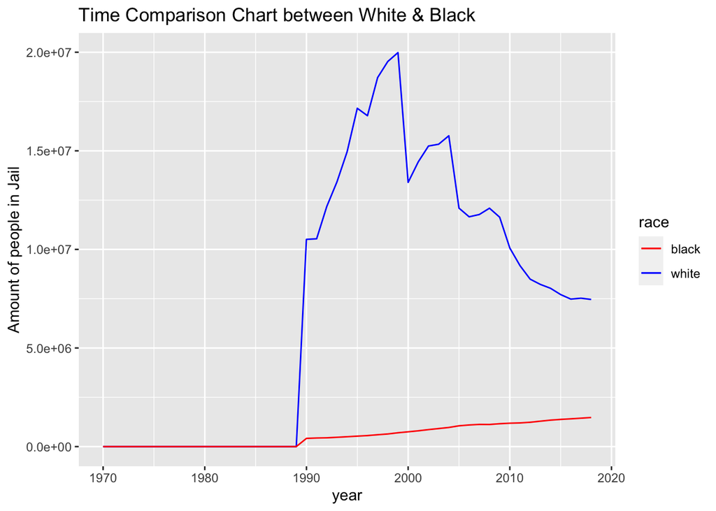

### Variable Comparison Chart

Include a chart. Make sure to describe why you included the chart, and what patterns emerged

The second chart that you will create and include will show how two different (continuous) variables are related to one another. Again, think carefully about what such a comparison means and what you want to communicate to your user (you may have to find relevant trends in the dataset first!). Here are some requirements to help guide your design:

- You must have clear x and y axis labels
- The chart needs a clear title
- If you choose to add a color encoding (not required), you need a legend for your different color and a clear legend title

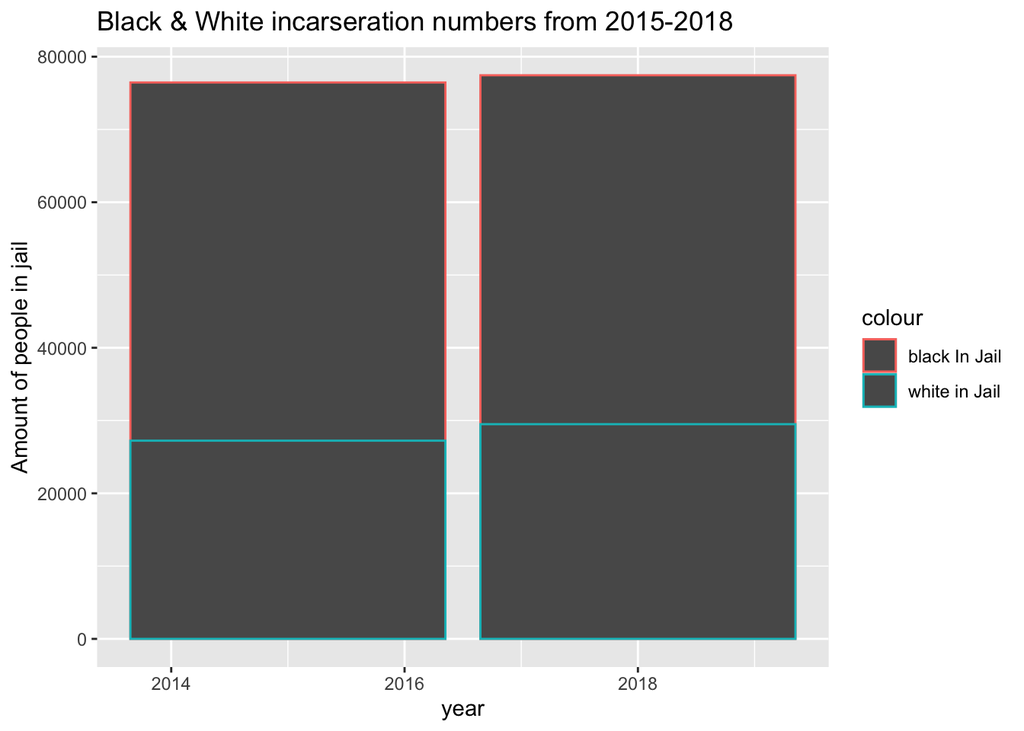

The bar chart as seen includes of an x axis representing years, and a y axis. As you can see, comparing 2015 - 2018, the number of black people in jails, outnumbers the number of white people in jail. This data is taken from the state of Alabama, which is a prodomitly white, 68.09% White, Black or African American: 26.64%, Two or more races: 1.89% Other race: 1.45%. I feel that the graph acurately alined with my ideology of the racial dempgraphics in prison.

### Map

Include a chart. Make sure to describe why you included the chart, and what patterns emerged

The last chart that you will create and include will show how a variable is distributed geographically. Again, think carefully about what such a comparison means and what you want to communicate to your user (you may have to find relevant trends in the dataset first!). Here are some requirements to help guide your design:

- Your map needs a title
- Your color scale needs a legend with a clear label
- Use a map based coordinate system to set the aspect ratio of your map

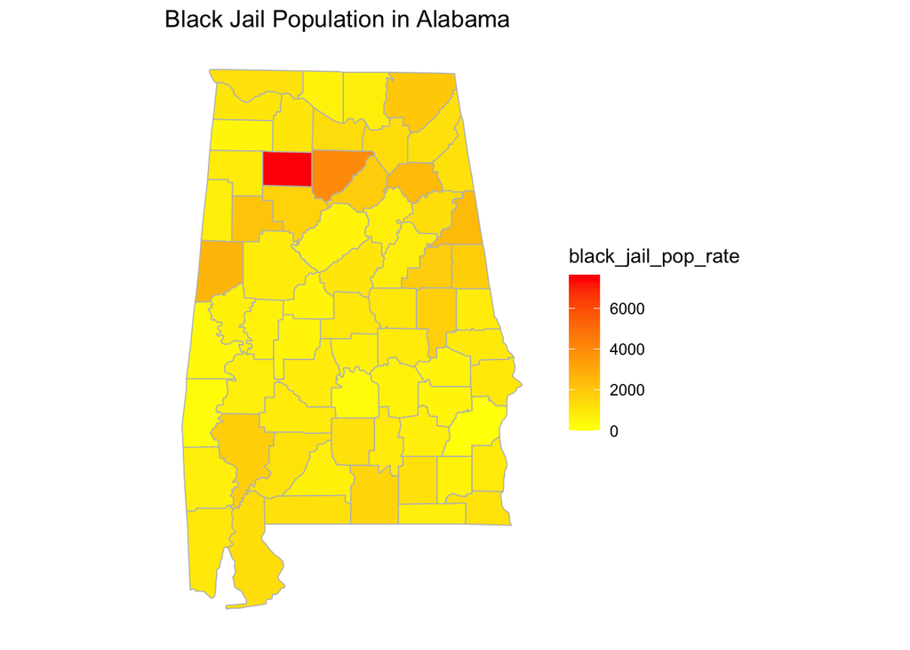